# juliaent_FinalR

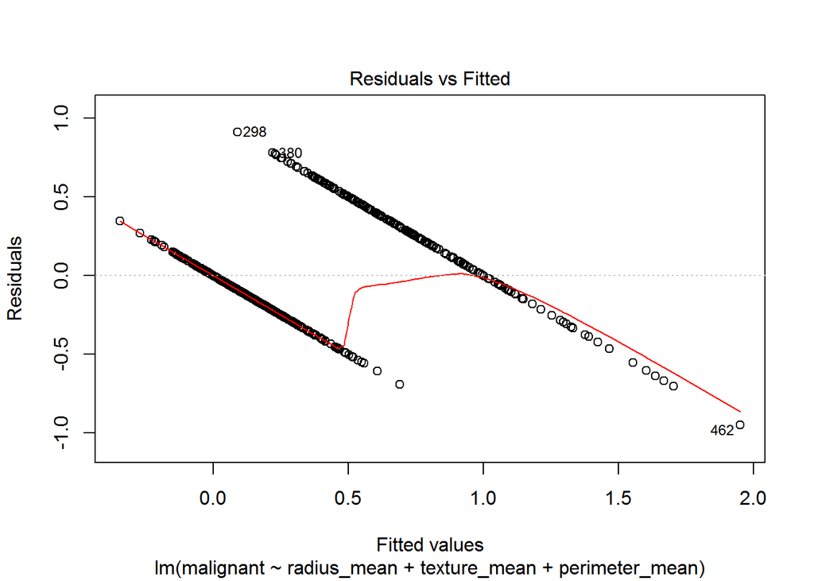

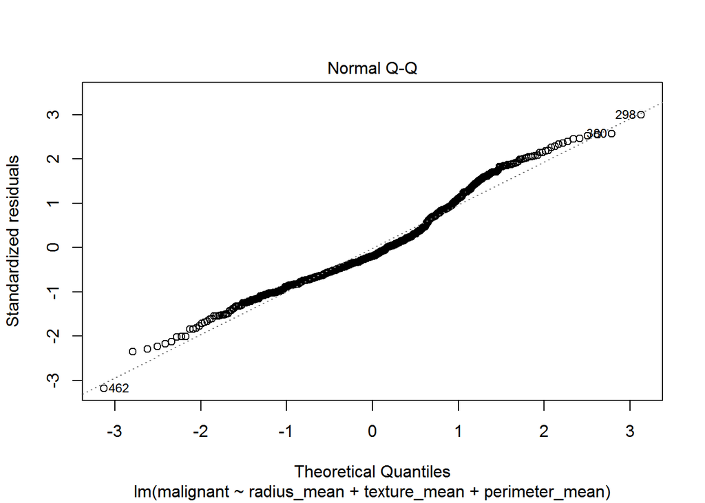

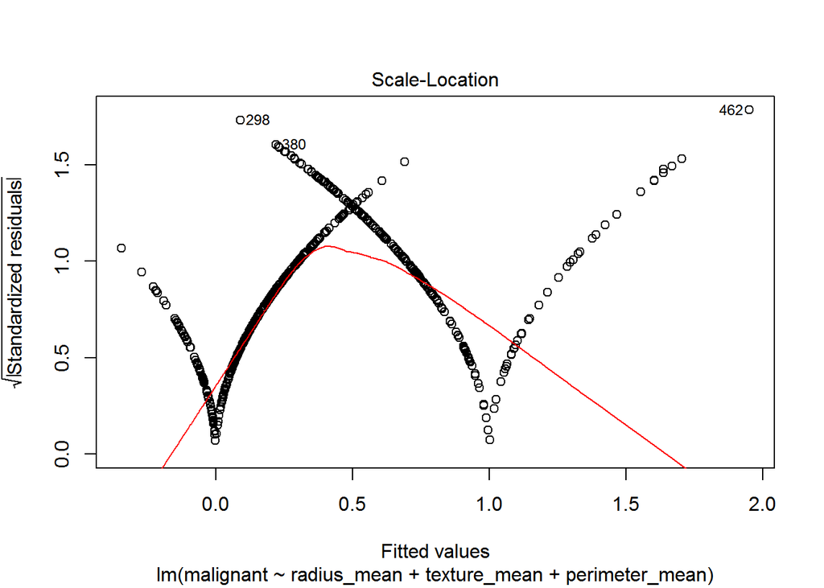

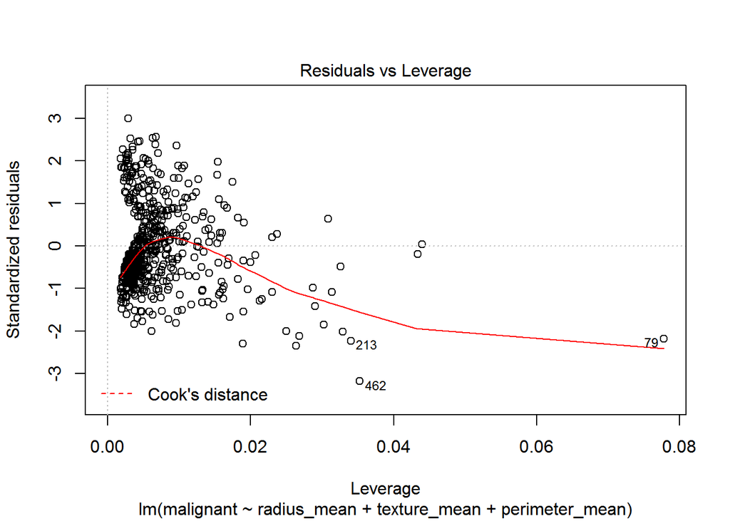

```r
plot(mod5)
```

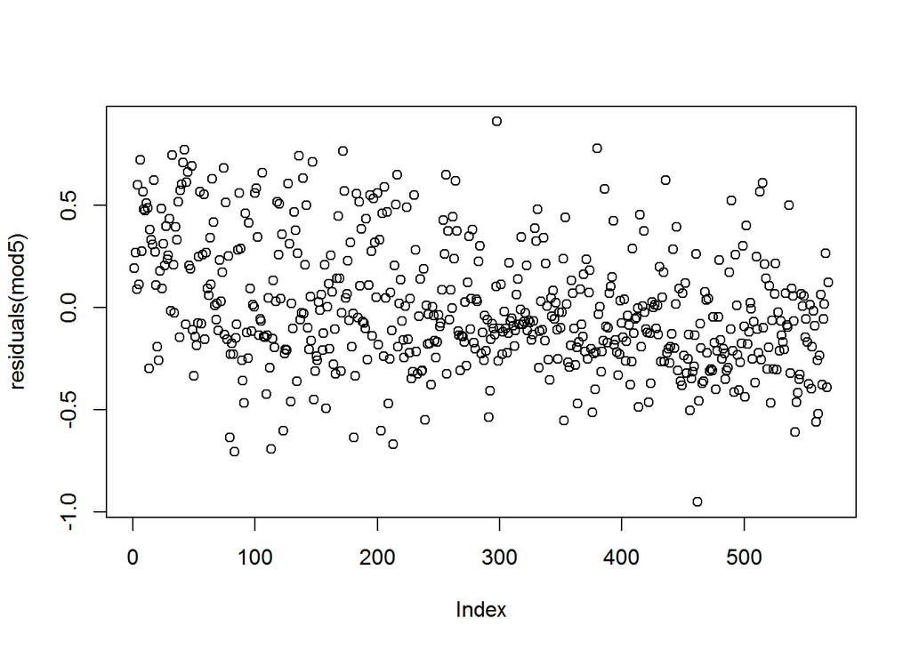

```r
plot(residuals(mod5))
```

```r
shapiro.test(residuals(mod5))
```

```
##
##  Shapiro-Wilk normality test
##
## data:  residuals(mod5)
## W = 0.97235, p-value = 6.994e-09
```

```r
vif(mod5)
```

```
##    radius_mean   texture_mean perimeter_mean
##     234.946329       1.129345     235.936638
```

```r
aov(mod5)
```

```
## Call:
##    aov(formula = mod5)
##
## Terms:
##                 radius_mean texture_mean perimeter_mean Residuals
## Sum of Squares     70.88779      4.75114        5.21036  52.16301
## Deg. of Freedom           1            1              1       565
##
## Residual standard error: 0.3038485
## Estimated effects may be unbalanced
```

## 7) BONUS/EXTRA CREDIT: Which independent variables are the most important in explaining whether a breast cancer tumor is malignant or not? Use the same 3 continuous independent variables you chose for question 6. cancer.

## “Perimeter_mean” is the most important in explaining whether a breast cancer tumor is malignant or not, closely followed by “radius_mean”, “texture_mean” is the least important of these three variables.

```r
cor(cancer[, c("malignant", "radius_mean", "texture_mean", "perimeter_mean")], use="na.or.complete")
```

```
##                malignant radius_mean texture_mean perimeter_mean
## malignant      1.0000000   0.7300285    0.4151853      0.7426355
## radius_mean    0.7300285   1.0000000    0.3237819      0.9978553
## texture_mean   0.4151853   0.3237819    1.0000000      0.3295331
## perimeter_mean 0.7426355   0.9978553    0.3295331      1.0000000
```